# Implicit Differentiation

## Graphs of equations

An **equation** in $y$ and $x$ is an algebraic expression involving an equality with two (or more) variables. An example might be $x^2 + y^2 = 1$.

The **solutions** to an equation in the variables $x$ and $y$ are all points $(x,y)$ which satisfy the equation.

The **graph** of an equation is just the set of solutions to the equation represented in the Cartesian plane.

With this definition, the graph of a function $f(x)$ is just the graph of the equation $y = f(x)$.

In general, graphing an equation is more complicated than graphing a function. For a function, we know for a given value of $x$ what the corresponding value of $f(x)$ is through evaluation of the function. For equations, we may have 0, 1 or more $y$ values for a given $x$ and even more problematic is we may have no rule to find these values.

To plot such an equation in `Julia`, we can use the `ImplicitEquations` package, which is loaded when `CalculusWithJulia` is:

```julia
using CalculusWithJulia  # load `Plots`, `ImplicitEquations`, `Roots`, `SymPy`
gr()   # better graphics than plotly() here
```

```
Plots.GRBackend()
```

To plot the circle of radius $2$, we would first define a function of *two* variables:

```julia
f(x,y) = x^2 + y^2
```

```
f (generic function with 1 method)
```

This is a function of *two* variables, used here to express one side of an equation. `Julia` makes this easy to do–-just make sure two variables are in the signature of `f` when it is defined. Using functions like this, we can express our equation in the form $f(x,y) = c$ or $f(x,y) = g(x,y)$, the latter of which can be expressed as $h(x,y) = f(x,y) - g(x,y) = 0$. That is, only the form $f(x,y)=c$ is needed.

Then we use one of the logical operations–-`Lt`, `Le`, `Eq`, `Ge`, or `Gt`–-to construct a predicate to plot. This one describes $x^2 + y^2 = 2^2$:

```julia
r = Eq(f, 2^2)
```

```
ImplicitEquations.Pred(Main.WeaveSandBox5030181185.f, ==, 4)
```

There are unicode infix operators for each of these which make it easier to read at the cost of being harder to type in. This predicate would be written as `f ⩵ 2^2` where `⩵` is **not** two equals signs, but rather typed with `\Equal[tab]`.)

These "predicate" objects can be passed to `plot` for visualization:

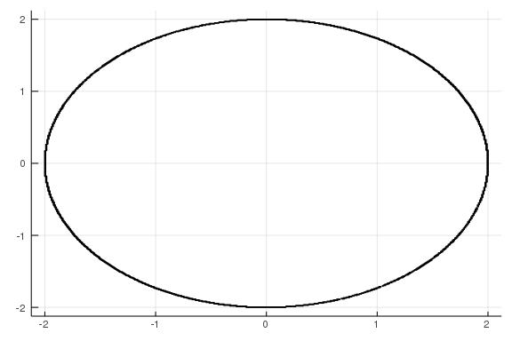

```julia
plot(r)
```

Of course, more complicated equations are possible and the steps are similar–-only the function definition is more involved. For example, the [Devils curve](http://www-groups.dcs.st-and.ac.uk/~history/Curves/Devils.html) has the form

\[ ~ y^4 - x^4 + ay^2 + bx^2 = 0 ~ \]

Here we draw the curve for a particular choice of $a$ and $b$. For illustration purposes, a narrower viewing window than the default of $[-5,5] \times [-5,5]$ is specified below using `xlims` and `ylims`:

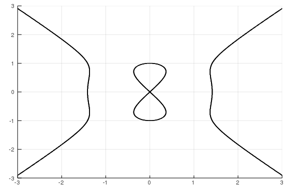

```julia
a,b = -1,2
f(x,y) =  y^4 - x^4 + a*y^2 + b*x^2
plot(Eq(f, 0), xlims=(-3,3), ylims=(-3,3))
```

The rendered plots look "blocky" due to the algorithm used to plot the equations. As there is no rule defining $(x,y)$ pairs to plot, a search by regions is done. A region is initially labeled undetermined. If it can be shown that for any value in the region the equation is true (equations can also be inequalities), the region is colored black. If it can be shown it will never be true, the region is dropped. If a black-and-white answer is not clear, the region is subdivided and each subregion is similarly tested. This continues until the remaining undecided regions are smaller than some threshold. Such regions comprise a boundary, and here are also colored black. Only regions are plotted–-not $(x,y)$ pairs–so the results are blocky. Pass larger values of $N=M$ (with defaults of $8$) to `plot` to lower the threshold at the cost of longer computation times.

### The IntervalConstraintProgramming package

The `IntervalConstraintProgramming` package also can be used to graph implicit equations. For certain problem descriptions it is significantly faster and makes better graphs. The usage is slightly more involved:

We specify a problem using the `@constraint` macro. Using a macro allows expressions to involve free symbols, so the problem is specified in an equation-like manner:

```julia
using IntervalArithmetic, IntervalConstraintProgramming
S = @constraint x^2 + y^2 <= 2
```

```
Separator:
  - variables: x, y
  - expression: x ^ 2 + y ^ 2 ∈ [-∞, 2]
```

The right hand side must be a number.

The area to plot over must be specified as an `IntervalBox`, basically a pair of intervals. The interval $[a,b]$ is expressed through `a..b`.

```julia
X = IntervalBox(-3..3, -3..3)
```

```
[-3, 3] × [-3, 3]
```

```julia
r = pave(S, X)
```

```
Paving:
- tolerance ϵ = 0.01
- inner approx. of length 1152
- boundary approx. of length 1156
```

We can plot either the boundary, the interior, or both.

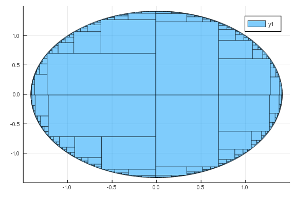

```julia
plot(r.inner)       # plot interior; use r.boundary for boundary
```

## Tangent lines, implicit differentiation

In general though, we may not be able to solve for $y$ in terms of $x$. What then?

The idea is to *assume* that $y$ is representable by some function of $x$. This makes sense, moving on the curve from $(x,y)$ to some nearby point, means changing $x$ will cause some change in $y$. This assumption is only made *locally*–-basically meaning a complicated graph is reduced to just a small, well-behaved, section of its graph.

With this assumption, asking what $dy/dx$ is has an obvious meaning – what is the slope of the tangent line to the graph at $(x,y)$.

The method of implicit differentiation allows this question to be investigated. It begins by differentiating both sides of the equation assuming $y$ is a function of $x$ to derive a new equation involving $dy/dx$.

For example, starting with $x^2 + y^2 = 1$, differentiating both sides in $x$ gives:

\[ ~ 2x + 2y\cdot \frac{dy}{dx} = 0. ~ \]

The chain rule was used to find $d/dx(y^2) = 2y \cdot dy/dx$. From this we can solve for $dy/dx$ (the resulting equations are linear in $dy/dx$, so can always be solved explicitly):

\[ ~ dy/dx = -x/y ~ \]

This says the slope of the tangent line depends on the point $(x,y)$ through the formula $-x/y$.

As a check, we compare to what we would have found had we solved for $y= \sqrt{1 - x^2}$ (for $(x,y)$ with $y \geq 0$). We would have found: $dy/dx = 1/2 \cdot 1/\sqrt{1 - x^2} \cdot -2x$. Which can be simplified to $-x/y$. This should show that the method above–-assuming $y$ is a function of $x$ and differentiating–-is not only more general, but can even be easier.

The name–-*implicit differentiation*–-comes from the assumption that $y$ is implicitly defined in terms of $x$. According to the [Implicit Function Theorem](http://en.wikipedia.org/wiki/Implicit_function_theorem) the above method will work provided the curve has sufficient smoothness near the point $(x,y)$.

##### Examples

Consider the [serpentine](http://www-history.mcs.st-and.ac.uk/Curves/Serpentine.html) equation

\[ ~ x^2y + a\cdot b \cdot y - a^2 \cdot x = 0, \quad a\cdot b > 0. ~ \]

For $a = 2, b=1$ we have the graph:

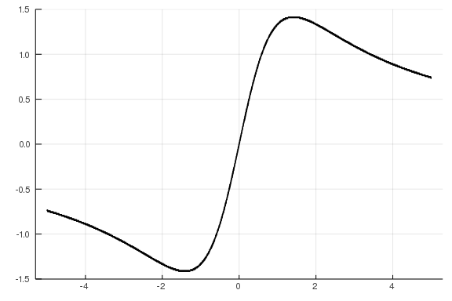

```julia
a, b = 2, 1
f(x,y) = x^2*y + a * b * y - a^2 * x
plot(Eq(f, 0))
```

We can see that at each point in the viewing window the tangent line exists due to the smoothness of the curve. Moreover, at a point $(x,y)$ the tangent will have slope $dy/dx$ satisfying:

\[ ~ 2xy + x^2 \frac{dy}{dx} + a\cdot b \frac{dy}{dx} - a^2 = 0. ~ \]

Solving, yields:

\[ ~ \frac{dy}{dx} = \frac{a^2 - 2xy}{ab + x^2}. ~ \]

In particular, the point $(0,0)$ is always on this graph, and the tangent line will have positive slope $a^2/(ab) = a/b$.

The [eight](http://www-history.mcs.st-and.ac.uk/Curves/Eight.html) curve has representation

\[ ~ x^4 = a^2(x^2-y^2), \quad a \neq 0. ~ \]

A graph for $a=3$ shows why it has the name it does:

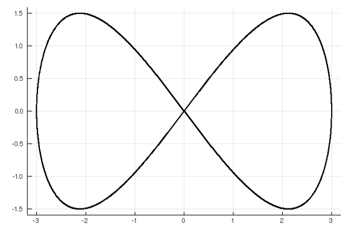

```julia
a = 3
f(x,y) = x^4 - a^2*(x^2 - y^2)
plot(Eq(f, 0))
```

The tangent line at $(x,y)$ will have slope, $dy/dx$ satisfying:

\[ ~ 4x^3 = a^2 \cdot (2x - 2y \frac{dy}{dx}). ~ \]

Solving gives:

\[ ~ \frac{dy}{dx} = -\frac{4x^3 - a^2 \cdot 2x}{a^2 \cdot 2y}. ~ \]

The point $(3,0)$ can be seen to be a solution to the equation and should have a vertical tangent line. This also is reflected in the formula, as the denominator is $a^2\cdot 2 y$, which is $0$ at this point, whereas the numerator is not.

##### Example

The quotient rule can be hard to remember, unlike the product rule. No reason to despair, the product rule plus implicit differentiation can be used to recover the quotient rule. Suppose $y=f(x)/g(x)$, then we could also write $y g(x) = f(x)$. Differentiating implicitly gives:

\[ ~ \frac{dy}{dx} g(x) + y g'(x) = f'(x). ~ \]

Solving for $dy/dx$ gives:

\[ ~ \frac{dy}{dx} = \frac{f'(x) - y g'(x)}{g(x)}. ~ \]

Not quite what we expect, perhaps, but substituting in $f(x)/g(x)$ for $y$ gives us the usual formula:

\[ ~ \frac{dy}{dx} = \frac{f'(x) - \frac{f(x)}{g(x)} g'(x)}{g(x)} = \frac{f'(x) g(x) - f(x) g'(x)}{g(x)^2}. ~ \]

In this example we mix notations using $g'(x)$ to represent a derivative of $g$ with respect to $x$ and $dy/dx$ to represent the derivative of $y$ with respect to $x$. This is done to emphasize the value that we are solving for. It is just a convention though, we could just as well have used the "prime" notation for each.

##### Example: Graphing a tangent line

Let's see how to add a graph of a tangent line to the graph of an equation. Tangent lines are tangent at a point, so we need a point to discuss.

```julia
F(x,y) = x^2 + y^2

a,b = sqrt(2)/2, -sqrt(2)/2

m = -a/b
tl(x) = b + m * (x-a)
```

```
tl (generic function with 1 method)
```

Now we want to plot *both* $F ⩵ 1$ and the tangent line. This can be done with two layers:

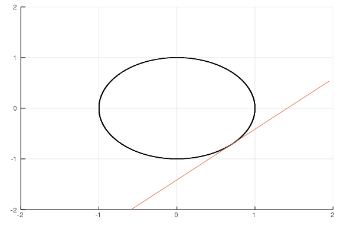

```julia
f(x,y) = x^2 + y^2
plot(Eq(f, 1), xlims=(-2, 2), ylims=(-2, 2))
plot!(tl)
```

##### Example

When we assume $y$ is a function of $x$, it may not be feasible to actually find the function algebraically. However, in many cases one can be found numerically. Suppose $F(x,y) = c$ describes the equation. Then for a fixed $x$, $y(x)$ solves $F(x,y(x))) - c = 0$, so $y(x)$ is a zero of a known function. As long as we can piece together which $y$ goes with which, we can find the function.

For example, [folium](http://www-history.mcs.st-and.ac.uk/Curves/Foliumd.html) of Descartes has the equation

\[ ~ x^3 + y^3 = 3axy. ~ \]

Setting $a=1$ we have the graph:

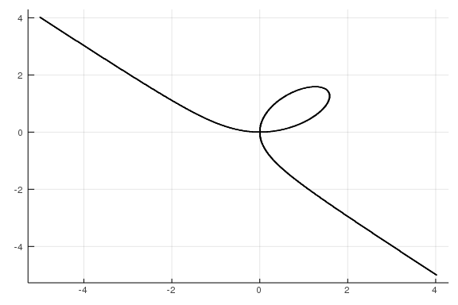

```julia
a = 1
F(x,y) = x^3 + y^3 - 3*a*x*y
plot(Eq(F,0))
```

We can solve for the lower curve, $y$, as a function of $x$, as follows:

```julia
y1(x) = minimum(find_zeros(y->F(x,y), -10, 10))  # find_zeros from `Roots`
```

```
y1 (generic function with 1 method)
```

This gives the lower part of the curve, which we can plot with:

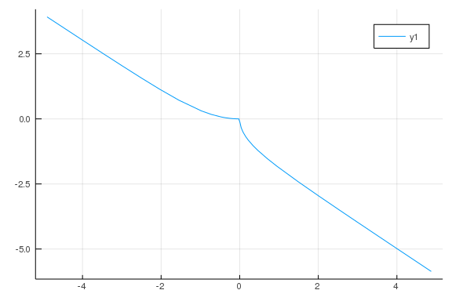

```julia
plot(y1, -5, 5)
```

Though, in this case, the cubic equation would admit a closed-form solution, the approach illustrated applies more generally.

## Using SymPy for computation

`SymPy` can be used to perform implicit differentiation. The three steps are similar: we assume $y$ is a function of $x$, *locally*; differentiate both sides; solve the result for $dy/dx$.

Let's do so for the [Trident of Newton](http://www-history.mcs.st-and.ac.uk/Curves/Trident.html), which is represented in Cartesian form as follows:

\[ ~ xy = cx^3 + dx^2 + ex + h. ~ \]

To approach this task in `SymPy`, we begin by defining our symbolic expression. For now, we keep the parameters as symbolic values:

```julia
@vars a b c d x y
ex = x*y - (a*c^3 + b*x^2 + c*x + d)
```

\begin{equation*}- a c^{3} - b x^{2} - c x - d + x y\end{equation*}

To express that `y` is a locally a function of `x`, we use a "symbolic function" object:

```julia
u = SymFunction("u")
```

\begin{align*}u\end{align*}

Defining a symbolic function is done with the command `SymFunction`. (This command's name is slightly modified from that when using SymPy under `Python`.) The object `u` is the symbolic function, and `u(x)` a symbolic expression involving a symbolic function. This is what we will use to refer to `y`.

Assume $y$ is a function of $x$, called `u(x)`, this substitution is just a renaming:

```julia
ex1 = ex(y => u(x))
```

\begin{equation*}- a c^{3} - b x^{2} - c x - d + x u{\left (x \right )}\end{equation*}

At this point, we differentiate both sides in `x`:

```julia
ex2 = diff(ex1, x)
```

\begin{equation*}- 2 b x - c + x \frac{d}{d x} u{\left (x \right )} + u{\left (x \right )}\end{equation*}

The next step is solve for $dy/dx$–-the lone answer to the linear equation–-which is done as follows:

```julia
dydx = diff(u(x), x)
ex3 = solve(ex2, dydx)[1]    # pull out lone answer with [1] indexing
```

\begin{equation*}\frac{2 b x + c - u{\left (x \right )}}{x}\end{equation*}

As this represents an answer in terms of `u(x)`, we replace that term with the original variable:

```julia
dydx = ex3(u(x) => y)
```

\begin{equation*}\frac{2 b x + c - y}{x}\end{equation*}

If `x` and `y` are the variable names, this function will combine the steps above:

```julia
function dy_dx(eqn)
  u = SymFunction("u")
  eqn1 = eqn(y => u(x))
  eqn2 = solve(diff(eqn1, x), diff(u(x), x))[1]
  eqn2(u(x) => y)
end
```

```
dy_dx (generic function with 1 method)
```

Let $a = b = c = d = 1$, then $(1,4)$ is a point on the curve. We can draw a tangent line to this point with these commands:

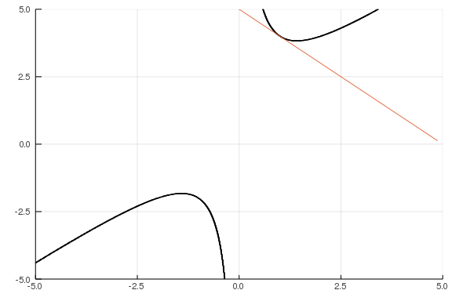

```julia
H = ex(a=>1, b=>1, c=>1, d=>1)
x0, y0 = 1, 4
m = dydx(x=>1, y=>4, a=>1, b=>1, c=>1, d=>1)
plot(Eq(lambdify(H), 0), xlims=(-5,5), ylims=(-5,5))
plot!(y0 + m * (x-x0))
```

Basically all the same steps as if done "by hand." Some effort could have been saved in plotting, had values for the parameters been substituted initially, but not doing so shows their dependence in the derivative.

The use of `lambdify` is needed to turn the symbolic expression, `H`, into a function, as `ImplicitEquations` expects functions in its predicates.

While `SymPy` itself has the `plot_implicit` function for plotting implicit equations, this works only with `PyPlot`, not `Plots`, so we use the `ImplicitEquations` package in these examples.

## Higher order derivatives

Implicit differentiation can be used to find $d^2y/dx^2$ or other higher-order derivatives. At each stage, the same technique is applied. The only "trick" is that some simplifications can be made.

For example, consider $x^3 - y^3=3$. To find $d^2y/dx^2$, we first find $dy/dx$:

\[ ~ 3x^2 - (3y^2 \frac{dy}{dx}) = 0. ~ \]

We could solve for $dy/dx$ at this point–-it always appears as a linear factor–-to get:

\[ ~ \frac{dy}{dx} = \frac{3x^2}{3y^2} = \frac{x^2}{y^2}. ~ \]

However, we differentiate the first equation, as we generally try to avoid the quotient rule

\[ ~ 6x - (6y \frac{dy}{dx} \cdot \frac{dy}{dx} + 3y^2 \frac{d^2y}{dx^2}) = 0. ~ \]

Again, if must be that $d^2y/dx^2$ appears as a linear factor, so we can solve for it:

\[ ~ \frac{d^2y}{dx^2} = \frac{6x - 6y (\frac{dy}{dx})^2}{3y^2}. ~ \]

It isn't so pretty, but that's all it takes.

To visualize, we plot implicitly and notice that:

- as we change quadrants from the third to the fourth to the first the concavity changes from down to up to down, as the sign of the second derivative changes from negative to positive to negative;
- and that at these inflection points, the "tangent" line is vertical when $y=0$ and flat when $x=0$.

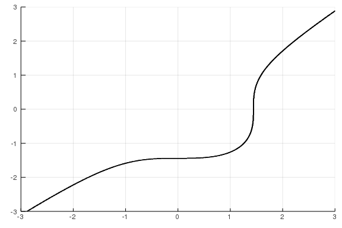

```julia
F(x,y) = x^3 - y^3
plot(Eq(F, 3),  xlims=(-3, 3), ylims=(-3, 3))
```

The same problem can be done symbolically. The steps are similar, though the last step (replacing $x^3 - y^3$ with $3$) isn't done without explicitly asking.

```julia
@vars x y
u = SymFunction("u")

eqn    = F(x,y) - 3
eqn1   = eqn(y => u(x))
dydx   = solve(diff(eqn1,x), diff(u(x), x))[1]        # 1 solution
d2ydx2 = solve(diff(eqn1, x, 2), diff(u(x),x, 2))[1]  # 1 solution
eqn2   = d2ydx2(diff(u(x), x) => dydx, u(x) => y)
simplify(eqn2)
```

\begin{equation*}\frac{2 x \left(- x^{3} + y^{3}\right)}{y^{5}}\end{equation*}

## Inverse functions

As mentioned, an [inverse](http://en.wikipedia.org/wiki/Inverse_function) function for $f(x)$ is a function $g(x)$ satisfying: $y = f(x)$ if and only if $g(y) = x$ for all $x$ in the domain of $f$ and $y$ in the range of $f$.

In short, both $f \circ g$ and $g \circ f$ are identify functions on their respective domains. As inverses are unique, their notation, $f^{-1}(x)$, reflects the name of the related function. function.

The chain rule can be used to give the derivative of an inverse function when applied to $f(f^{-1}(x)) = x$. Solving gives, $[f^{-1}(x)]' = 1 / f'(g(x))$.

This is great–-if we can remember the rules. If not, sometimes implicit differentiation can also help.

Consider the inverse function for the tangent, which exists when the domain of the tangent function is restricted to $(-\pi/2, \pi/2)$. The function solves $y = \tan^{-1}(x)$ or $\tan(y) = x$. Differentiating this yields:

\[ ~ \sec(y)^2 \frac{dy}{dx} = 1. ~ \]

But $\sec(y)^2 = 1 + x^2$, as can be seen by right-triangle trigonometry. This yields the formula $dy/dx = [\tan^{-1}(x)]' = 1 / (1 + x^2)$.

##### Example

For a more complicated example, suppose we have a moving trajectory $(x(t), y(t))$. The angle it makes with the origin satisfies

\[ ~ \tan(\theta(t)) = \frac{y(t)}{x(t)}. ~ \]

Suppose $\theta(t)$ can be defined in terms of the inverse to some function ($\tan^{-1}(x)$). We can differentiate implicitly to find $\theta'(t)$ in terms of derivatives of $y$ and $x$:

\[ ~ \sec^2(\theta(t)) \cdot \theta'(t) = \frac{y'(t) x(t) - y(t) x'(t)}{x(t))^2}. ~ \]

But $\sec^2(\theta(t)) = (r(t)/x(t))^2 = (x(t)^2 + y(t)^2) / x(t)^2$, so moving to the other side the secant term gives an explicit, albeit complicated, expression for the derivative of $\theta$ in terms of the functions $x$ and $y$:

\[ ~ \theta'(t) = \frac{x^2}{x^2(t) + y^2(t)} \cdot \frac{y'(t) x(t) - y(t) x'(t)}{x(t))^2} = \frac{y'(t) x(t) - y(t) x'(t)}{x^2(t) + y^2(t)}. ~ \]

This could have been made easier, had we leveraged the result of the previous example.

## Example from physics

Many problems are best done with implicit derivatives. A video showing such a problem along with how to do it analytically is [here](http://ocw.mit.edu/courses/mathematics/18-01sc-single-variable-calculus-fall-2010/unit-2-applications-of-differentiation/part-b-optimization-related-rates-and-newtons-method/session-32-ring-on-a-string/).

This video starts with a simple question:

> If you have a rope and heavy ring, where will the ring position itself due to gravity?

Well, suppose you hold the rope in two places, which we can take to be $(0,0)$ and $(a,b)$. Then let $(x,y)$ be all the possible positions of the ring that hold the rope taught. Then we have this picture:

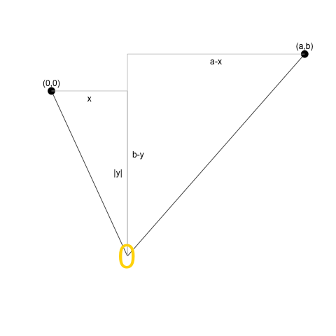

Ring on string figure.

Since the length of the rope does not change, we must have for any admissible $(x,y)$ that:

\[ ~ L = \sqrt{x^2 + y^2} + \sqrt{(a-x)^2 + (b-y)^2}, ~ \]

where these terms come from the two hypotenuses in the figure, as computed through Pythagorean's theorem.

> If we assume that the ring will minimize the value of y subject to this constraint, can we solve for y?

We create a function to represent the equation:

```julia
F(x, y, a, b) = sqrt(x^2 + y^2) + sqrt((a-x)^2 + (b-y)^2)
```

```
F (generic function with 2 methods)
```

To illustrate, we need specific values of $a$, $b$, and $L$:

```julia
a, b, L = 3, 3, 10      # L > sqrt{a^2 + b^2}
F(x, y) = F(x, y, a, b)
```

```
F (generic function with 2 methods)
```

Our values $(x,y)$ must satisfy $f(x,y) = L$. Let's graph:

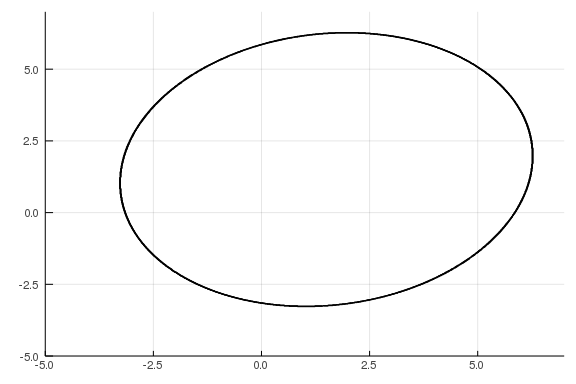

```julia
plot(Eq(F, L), xlims=(-5, 7), ylims=(-5, 7))
```

The graph is an ellipse, though slightly tilted.

Okay, now to find the lowest point. This will be when the derivative is $0$. We solve by assuming $y$ is a function of $x$ called `u`:

```julia
@vars a b L x y
u = SymFunction("u")
```

\begin{align*}u\end{align*}

```julia
F(x,y,a,b) = sqrt(x^2 + y^2) + sqrt((a-x)^2 + (b-y)^2)
eqn = F(x,y,a,b) - L
```

\begin{equation*}- L + \sqrt{x^{2} + y^{2}} + \sqrt{\left(a - x\right)^{2} + \left(b - y\right)^{2}}\end{equation*}

```julia
eqn1 = diff(eqn(y => u(x)), x)
eqn2 = solve(eqn1, diff(u(x), x))[1]
dydx  = eqn2(u(x) => y)
```

\begin{equation*}\frac{a \sqrt{x^{2} + y^{2}} - x \sqrt{x^{2} + y^{2}} - x \sqrt{\left(a - x\right)^{2} + \left(b - y\right)^{2}}}{- b \sqrt{x^{2} + y^{2}} + y \sqrt{x^{2} + y^{2}} + y \sqrt{\left(a - x\right)^{2} + \left(b - y\right)^{2}}}\end{equation*}

We are looking for when the tangent line has 0 slope, or when `dydx` is 0:

```julia
cps = solve(dydx, x)
```

\[ \left[ \begin{array}{r}\frac{a y}{b}\\\frac{a y}{- b + 2 y}\end{array} \right] \]

There are two answers, as we could guess from the graph, but we want the one for the smallest value of $y$, which is the second.

The values of dydx depend on any pair (x,y), but our solution must also satisfy the equation. That is for our value of x, we need to find the corresponding y. This should be possible by substituting:

```julia
eqn1 = eqn(x => cps[2])
```

\begin{equation*}- L + \sqrt{\frac{a^{2} y^{2}}{\left(- b + 2 y\right)^{2}} + y^{2}} + \sqrt{\left(b - y\right)^{2} + \left(- \frac{a y}{- b + 2 y} + a\right)^{2}}\end{equation*}

We would try to solve `eqn1` for `y` with `solve(eqn1, y)`, but `SymPy` can't complete this problem. Instead, we will approach this numerically using `find_zero` from the `Roots` package. We make the above a function of `y` alone

```julia
eqn2 = eqn1(a=>3, b=>3, L=>10)
ystar = find_zero(eqn2, -3)
```

```
-3.269696007084728
```

Okay, now we need to put this value back into our expression for the `x` value and also substitute in for the parameters:

```julia
xstar = N(cps[2](y => ystar, a =>3, b => 3, L => 3))
```

```
1.0282718234751367
```

Our minimum is at `(xstar, ystar)`, as this graphic shows:

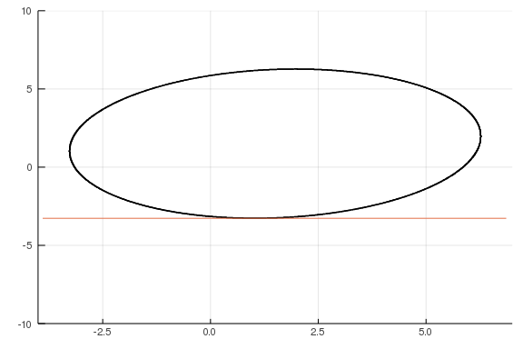

```julia
F(x,y) = F(x,y, 3, 3)
tl(x) = ystar + 0 * (x- xstar)
plot(Eq(F, 10), xlims=(-4, 7), ylims=(-10, 10))
plot!(tl)
```

If you watch the video linked to above, you will see that the surprising fact here is the resting point is such that the angles formed by the rope are the same. Basically this makes the tension in both parts of the rope equal, so there is a static position (if not static, the ring would move and not end in the final position). We can verify this fact numerically by showing the arctangents of the two triangles are the same up to a sign (and slight round-off error):

```julia
a0, b0 = 0,0   # the foci of the ellipse are (0,0) and (3,3)
a1, b1 = 3, 3
atan((b0 - ystar)/(a0 - xstar)) + atan((b1 - ystar)/(a1 - xstar)) # 0
```

```
0.0
```

Now, were we lucky and just happened to take $a=3$, $b = 3$ in such a way to make this work? Well, no. But convince yourself by doing the above for different values of $b$.

## Questions

###### Question

Is $(1,1)$ on the graph of

\[ ~ x^2 - 2xy + y^2 = 1? ~ \]

Yes

No

###### Question

For the equation

\[ ~ x^2y + 2y - 4 x = 0, ~ \]

if $x=4$, what is a value for $y$ such that $(x,y)$ is a point on the graph of the equation?

###### Question

For the equation

\[ ~ (y-5)\cdot \cos(4\cdot \sqrt{(x-4)^2 + y^2)} = x\cdot\sin(2\sqrt{x^2 + y^2}) ~ \]

is the point $(5,0)$ a solution?

Yes

No

##### Question

Let $(x/3)^2 + (y/2)^2 = 1$. Find the slope of the tangent line at the point $(3/\sqrt{2}, 2/\sqrt{2})$.

###### Question

The [lame](http://www-history.mcs.st-and.ac.uk/Curves/Lame.html) curves satisfy:

\[ ~ (\frac{x}{a})^n + (\frac{y}{b})^n = 1. ~ \]

Find a *positive* value of $y$ when $x=1/2$.

What expression gives $dy/dx$?

$ -(y/x) \cdot (x/a)^n \cdot (y/b)^{-n}$

$b \cdot (1 - (x/a)^n)^{1/n}$

$-(x/a)^n / (y/b)^n$

###### Question

Let $y - x^2 = -\log(x)$. At the point $(1/2, 0.9431...)$, the graph has a tangent line. Find this line, then find its intersection point with the $y$ axes.

This intersection is:

###### Question

The [witch](http://www-history.mcs.st-and.ac.uk/Curves/Witch.html) of [Agnesi](http://www.maa.org/publications/periodicals/convergence/mathematical-treasures-maria-agnesis-analytical-institutions) is the curve given by the equation

\[ ~ y(x^2 + a^2) = a^3. ~ \]

If $a=1$, numerically find a a value of $y$ when $x=2$.

What expression yields $dy/dx$ for this curve:

$-2xy/(x^2 + a^2)$

$a^3/(x^2 + a^2)$

$2xy / (x^2 + a^2)$

###### Question

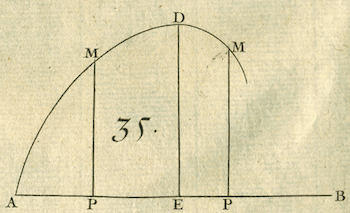

Image number 35 from L'Hospitals calculus book (the first). Given a description of the curve, identify the point $E$ which maximizes the height.

The figure above shows a problem appearing in L'Hospital's first calculus book. Given a function defined implicitly by $x^3 + y^3 = axy$ (with $AP=x$, $AM=y$ and $AB=a$) find the point $E$ that maximizes the height. In the [AMS feature column](http://www.ams.org/samplings/feature-column/fc-2016-05) this problem is illustrated and solved in the historical manner, with the comment that the concept of implicit differentiation wouldn't have occurred to L'Hospital.

Using Implicit differentiation, find when $dy/dx = 0$.

$y=a/(3x^2)$

$y=3x^2/a$

$y^2=a/(3x)$

$y^2 = 3x/a$

Substituting the correct value of $y$, above, into the defining equation gives what value for $x$:

$x=(1/3) a^2 2^{1/2}$

$x=(1/2) a^3 3^{1/3}$

$x=(1/3) a 2^{1/3}$

$x=(1/2) a 2^{1/2}$

###### Question

For the equation of an ellipse:

\[ ~ (\frac{x}{a})^2 + (\frac{y}{b})^2 = 1, ~ \]

compute $d^2y/dx^2$. Is this the answer?

\[ ~ \frac{d^2y}{dx^2} = -\frac{b^2}{a^2\cdot y} - \frac{b^4\cdot x^2}{a^4\cdot y^3} = -\frac{1}{y}\frac{b^2}{a^2}(1 + \frac{b^2 x^2}{a^2 y^2}). ~ \]

Yes

No

If $y>0$ is the sign positive or negative?

positive

negative

Can be both

If $x>0$ is the sign positive or negative?

positive

negative

Can be both

When $x>0$, the graph of the equation is...

concave up

concave down

both concave up and down